# AAA Project

```r
setwd("C:/Users/Nung Lian Sume/Desktop/AAA Challenge")

library(ggplot2)
library(ggthemes)
library(GGally)
#library(rattle)
library(rpart.plot)
library(RColorBrewer)
library(Amelia)
library(vcd)
library(caret)
```

## 1.Getting Data

```r
rawtraining <- read.csv('SAStraining.csv',stringsAsFactors = FALSE)
finaltest <- read.csv('SAStest.csv',stringsAsFactors = FALSE)

#Initial Data Preparation
rawtraining$readmitted <- as.factor(rawtraining$readmitted)
variables <- names(rawtraining)
initialExcludes <- c("patientID","admissionDate")

train <- rawtraining[,!variables %in% initialExcludes]
```

## 2.Handling Missing Values

### Check variables which have high missing values

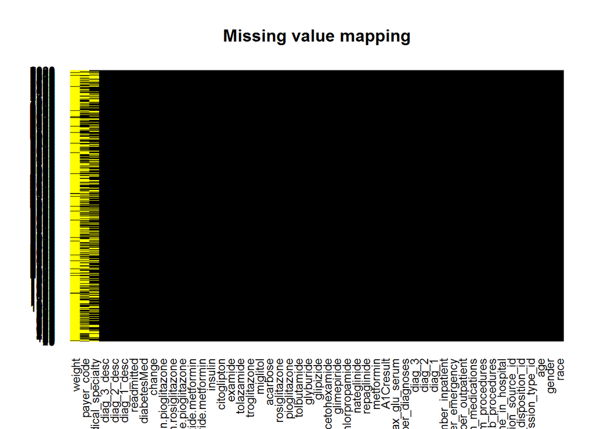

```r
missmap(train,main = "Missing value mapping",
        col = c('yellow','black'),
        legend = FALSE)
```

The dentified variables which have high missing values are - weight - payer_code - medical_specialty These variables will be delt with later.

```r
missingVars <- c("weight","payer_code","medical_specialty")
```

Check the number of missing value

```r
round(sum(is.na(train$weight))/nrow(train),2)
```

```
## [1] 0.96
```

```r
round(sum(is.na(train$payer_code))/nrow(train),2)
```

```
## [1] 0.53
```

```r
round(sum(is.na(train$medical_specialty))/nrow(train),2)
```

```
## [1] 0.41
```

### Check if the missing values has relationshp with readmittance

```r
train$weightR[!is.na(train$weight)] <- 'No-Missing'
train$weightR[is.na(train$weight)] <- 'Missing'

train$payer_codeR[!is.na(train$payer_code)] <- 'No-Missing'
train$payer_codeR[is.na(train$payer_code)] <- 'Missing'

train$medical_specialtyR[!is.na(train$medical_specialty)] <- 'No-Missing'
train$medical_specialtyR[is.na(train$medical_specialty)] <- 'Missing'
```

#### Weight

```r
weightTable <- table(train$readmitted,train$weightR)
print(weightTable)
```

```
##
##     Missing No-Missing
##   0    4630        121
##   1    3039        210
```

```r
round(prop.table(weightTable,margin = 2),2)
```

```
##
##     Missing No-Missing
##   0    0.60       0.37
##   1    0.40       0.63
```

```r
xWeight <- chisq.test(train$weightR,train$readmitted)
print(xWeight)
```

```
##
##  Pearson's Chi-squared test with Yates' continuity correction
##
## data:  train$weightR and train$readmitted
## X-squared = 73.643, df = 1, p-value < 2.2e-16
```

#### payer_code

```r
payerTable <- table(train$readmitted,train$payer_codeR)
print(payerTable)
```

```
##
##     Missing No-Missing
##   0    2529       2222
##   1    1722       1527
```

```r
round(prop.table(payerTable,margin = 2),2)
```

```
##
##     Missing No-Missing
##   0    0.59       0.59
##   1    0.41       0.41
```

```r
xPayer <- chisq.test(train$payer_codeR,train$readmitted)
print(xPayer)
```

```
##
##  Pearson's Chi-squared test with Yates' continuity correction
##
## data:  train$payer_codeR and train$readmitted
## X-squared = 0.032266, df = 1, p-value = 0.8574
```

Payer_code has a very balanced values for readmitted variables.

#### medical_specialty

```r
specialtyTable <- table(train$readmitted,train$medical_specialtyR)
print(specialtyTable)
```

```
##
##     Missing No-Missing
##   0    1761       2990
##   1    1486       1763
```

```r
round(prop.table(specialtyTable,margin = 2),2)
```

```
##
##     Missing No-Missing
##   0    0.54       0.63
##   1    0.46       0.37
```

```r
xSpecialty <- chisq.test(train$medical_specialtyR,train$readmitted)
print(xSpecialty)
```

```
##
##  Pearson's Chi-squared test with Yates' continuity correction
##
## data:  train$medical_specialtyR and train$readmitted
## X-squared = 59.805, df = 1, p-value = 1.047e-14
```

Medical_specialy also has a unbalance proportion for readmitted variables. Non-missing group of Medical_specialty has slightly higher proporiton of patients who are not readmitted, compared to the missing group.

Since the classification of missing and non-missing for Weight and Medical Specialty seems having a contribution to readmittance, these recoded variables are added into the training data set.

```r
train$weightR <- as.factor(train$weightR)
train$payer_codeR <- as.factor(train$payer_codeR)
train$medical_specialtyR <- as.factor(train$medical_specialtyR)
```

Currently the variables which have high missing values will be excluded from the traning data set temporarily and it will be repalced with other methods later.

```r
#Exclude fromt traiing data
train <- train[,!names(train) %in% missingVars]
```

### Check and Replace Missing values

Currently, varaibles which has a low missing values will be temporarily replaced with ‘NotKeyed’ code. - race - admission_type_id - admission_source_id - discharge_source_id

```r
train$race <- ifelse(train$race == "?","NotKeyed",train$race)
train$admission_type_id <- ifelse(train$admission_type_id == "","NotKeyed",train$admission_type_id)
train$admission_source_id <- ifelse(train$admission_source_id == "","NotKeyed",train$admission_source_id)
train$discharge_disposition_id <- ifelse(train$discharge_disposition_id == "","NotKeyed",train$discharge_disposition_id)
```

## 3.Cleaning and Restructuring Variables

Some variables such as Cleaning Diag_1, Diag_2 and Diag_3 needs to be cleaned. These three variables describe the most important diagnoses for the patients. Some of the Diag_2 are missing whiel there is a value for Diag_3. For such as Diag_3 value will be moved to Diag_2 and the Diag_3 will be repalced with NA.

```r
diagnosis <- rawtraining[c('diag_1','diag_2','diag_3','readmitted')]
```

### Creating Code Dictionary

Firstly, create the code dictioanly for these three variables, so that reference can be easily made and the describtion for theme can be deleted from the data.

```r
dia1 <- rawtraining[,c("diag_1","diag_1_desc")]
names(dia1) <- c('diag','description')
dia2 <- rawtraining[,c("diag_2","diag_2_desc")]
names(dia2) <- c('diag','description')
dia3 <- rawtraining[,c("diag_3","diag_3_desc")]
names(dia3) <- c('diag','description')

allDiag <- rbind(dia1,dia2,dia3)
allDiagUnique <- unique(allDiag)
allDiagUnique <- allDiagUnique[order(allDiagUnique$diag),]

print(nrow(allDiagUnique))
```

```
## [1] 619
```

```r
print(head(allDiagUnique,10))
```

```
##       diag                                     description
## 1937     ?
## 3953    11 Tuberculosis of lung, infiltrative, unspecified
## 7924   110              Dermatophytosis of scalp and beard
## 305    112                            Candidiasis of mouth
## 18192  117                                Rhinosporidiosis
## 8405   131          Urogenital trichomoniasis, unspecified
## 8363   135                                     Sarcoidosis
## 14136  136                                          Ainhum
## 14453  138             Late effects of acute poliomyelitis
## 7549   141            Malignant neoplasm of base of tongue
```

It was found that there are some codes that needs to do further checking such as 250, 250.01,250.02,250.3 etc..

```r
diag250 <- allDiagUnique[grepl('250',allDiagUnique$diag),]
diagnosis250 <- diagnosis[diagnosis$diag_1 %in% diag250$diag,]
print(head(diagnosis250,10))
```

```
##    diag_1 diag_2 diag_3 readmitted
## 14  250.8    799    401          0
## 15  250.7    440    707          0
## 20 250.82    707    731          0
## 30 250.11    276      ?          1
## 31  250.7    440    707          0
## 51 250.11    581    403          1
## 52  250.4    404    428          1
## 61  250.7    428    682          0
## 64  250.6    337      ?          0
## 69 250.02    276    427          1
```

This gorups represents diabetes, hence the following checking is done if regrouping them is a good idea.

```r
table(diagnosis250$diag_1,diagnosis250$readmitted)
```

```
##
##           0  1
##   250    12  6
##   250.01  6  2
##   250.02 30 27
##   250.03 18  4
##   250.1  13 12
##   250.11 40 26
##   250.12 20  5
##   250.13 40 13
##   250.2  10  1
##   250.21  1  0
##   250.22 13  9
##   250.23  5  2
##   250.3   0  4
##   250.31  0  2
##   250.32  1  0
##   250.33  2  2
##   250.4  14 13
##   250.41  2  8
##   250.42  3  4
##   250.43  1  2
##   250.52  0  1
##   250.6  43 33
##   250.7  35 33
##   250.8  58 48
##   250.81 12  6
##   250.82 16 13
##   250.83  4  4
##   250.92  2  3
##   250.93  4  1
```

```r
round(prop.table(table(diagnosis250$diag_1,diagnosis250$readmitted),margin=1),2)
```

```
##
##             0    1
##   250    0.67 0.33
##   250.01 0.75 0.25
##   250.02 0.53 0.47
##   250.03 0.82 0.18
##   250.1  0.52 0.48
##   250.11 0.61 0.39
##   250.12 0.80 0.20
##   250.13 0.75 0.25
##   250.2  0.91 0.09
##   250.21 1.00 0.00
##   250.22 0.59 0.41
##   250.23 0.71 0.29
##   250.3  0.00 1.00
##   250.31 0.00 1.00
##   250.32 1.00 0.00
##   250.33 0.50 0.50
##   250.4  0.52 0.48
##   250.41 0.20 0.80
##   250.42 0.43 0.57
##   250.43 0.33 0.67
##   250.52 0.00 1.00
##   250.6  0.57 0.43
##   250.7  0.51 0.49
##   250.8  0.55 0.45
##   250.81 0.67 0.33
##   250.82 0.55 0.45
##   250.83 0.50 0.50
##   250.92 0.40 0.60
##   250.93 0.80 0.20
```

Since the proporiton for readmitance for the groups are significantly different, it will no be a good idea to regroup them.

### Shifting/Reorganizing

The three variables such as diag_1,diag_2 and diag_3 are reorganized.

```r
#If the diag_1 is missing, replace with diag_2
diagnosis$diag_1 <- ifelse(diagnosis$diag_1 == '?',diagnosis$diag_2,diagnosis$diag_1)
#If the diag_2 is missing, replace with diag_3
diagnosis$diag_2 <- ifelse(diagnosis$diag_2 == '?',diagnosis$diag_3,diagnosis$diag_2)
#If diag_1 and diag_2 is the same, repalce diag_2 with diag 3
diagnosis$diag_2 <- ifelse(diagnosis$diag_1 == diagnosis$diag_2,diagnosis$diag_3,diagnosis$diag_2)
#If diag_2 and diag_3 is the same, repalce diag_3 with '?', if not with diag_3
diagnosis$diag_3 <- ifelse(diagnosis$diag_2 == diagnosis$diag_3,'?',diagnosis$diag_3)
```

```r
diagnosisMissing <- diagnosis[diagnosis$diag_1 == '?' |
                                diagnosis$diag_2 == '?' |
                                diagnosis$diag_3 == '?',]
head(diagnosisMissing,15)
```

```
##     diag_1 diag_2 diag_3 readmitted
## 1      723    719      ?          0
## 12     440    998      ?          1
## 30  250.11    276      ?          1
## 33     V57    724      ?          0
## 39     491    276      ?          0
## 41     618    218      ?          0
## 58     415    250      ?          0
## 64   250.6    337      ?          0
## 77     786    250      ?          0
## 102    722    250      ?          0
## 106    823    250      ?          1
## 138    493    250      ?          0
## 156    427    413      ?          1
## 165    536    276      ?          1
## 199    474 250.01      ?          0
```

### Replace Missing Values

The three variables have some missing values represented by ‘?’ and they are replaced by ‘NA’ value for easier data processing.

```r
fix_missing <- function(x,na.value){
  x[x==na.value] <- NA
  x
}
diagnosis[1:3] <- lapply(diagnosis[1:3],fix_missing,'?')
```

Merge diagnosis into the train dataset

```r
train[,c('diag_1','diag_2','diag_3')] <- NULL
diagnosis[,'readmitted'] <- NULL
train <- cbind(train,diagnosis)
```

## 4.Derive New Variables

#### No of Important Diagnosis

From the 3 diagnosis, a new variable is created to represent, how many important diagnosis is identified for each patient.

```r
#No of Important Diagnosis
train$No_Diags <- apply(train[,c('diag_1','diag_2','diag_3')],1,function(x) sum(!is.na(x)))
round(prop.table(table(train$No_Diags,train$readmitted),margin=1),2)
```

```
##
##        0    1
##   1 0.80 0.20
##   2 0.63 0.37
##   3 0.59 0.41
```

#### Hospice

In the discharge_disposition_id, it was found that ‘Hospice/Home’ and ‘Hospice/ Facility’ may represent patients who are likely to pass away. Hence, a preliminary check was done.

```r
hospicecode <- c("Hospice / home","Hospice / medical facility")
Hospice <- train[train$discharge_disposition_id %in% hospicecode,c('discharge_disposition_id','readmitted','No_Diags')]
```

Check if patients who were sent to Hospice were not readmitted (possibily died)

```r
round(prop.table(table(Hospice$discharge_disposition_id,Hospice$readmitted),margin = 1),2)
```

```
##
##                                 0    1
##   Hospice / home             0.95 0.05
##   Hospice / medical facility 0.87 0.13
```

It is found out that most of the patients who were sent to Hospice were not readmitted.

It is also checked with the vilidity of creating the number of important diagnosis and it is fond out hat most of them were diagnosed with 3 important diagnosis.

```r
round(prop.table(table(Hospice$discharge_disposition_id,Hospice$No_Diags),margin = 1),2)
```

```
##
##                                 2    3
##   Hospice / home             0.00 1.00
##   Hospice / medical facility 0.09 0.91
```

Hospice variable is added in the training data set.

```r
train$hospice <- ifelse(train$discharge_disposition_id %in% c("Hospice / home","Hospice / medical facility"), 1,0)
```

## 5.Check Zero /Low Variance Variables

```r
nzv <- nearZeroVar(train,saveMetrics = TRUE)
print(nzv)
```

```
##                            freqRatio percentUnique zeroVar   nzv
## race                        3.527928        0.0750   FALSE FALSE
## gender                      1.174504        0.0250   FALSE FALSE
## age                         1.188723        0.1250   FALSE FALSE
## admission_type_id           2.595020        0.0750   FALSE FALSE
## discharge_disposition_id    5.121436        0.2625   FALSE FALSE
## admission_source_id         1.671267        0.1250   FALSE FALSE
## time_in_hospital            1.050912        0.1750   FALSE FALSE
## num_lab_procedures          1.160976        1.3500   FALSE FALSE
## num_procedures              2.069947        0.0875   FALSE FALSE
## num_medications             1.036093        0.8125   FALSE FALSE
## number_outpatient          11.631491        0.2500   FALSE FALSE
## number_emergency           16.585202        0.1500   FALSE FALSE
## number_inpatient            4.615620        0.1375   FALSE FALSE
## number_diagnoses            2.614478        0.1125   FALSE FALSE
## max_glu_serum              26.834532        0.0500   FALSE  TRUE
## A1Cresult                   9.844118        0.0500   FALSE FALSE
## metformin                   4.305199        0.0500   FALSE FALSE
## repaglinide                85.782609        0.0500   FALSE  TRUE
## nateglinide               180.772727        0.0500   FALSE  TRUE
## chlorpropamide            887.777778        0.0375   FALSE  TRUE
## glimepiride                21.243017        0.0500   FALSE  TRUE
## acetohexamide               0.000000        0.0125    TRUE  TRUE
## glipizide                   7.510799        0.0500   FALSE FALSE
## glyburide                   8.493976        0.0500   FALSE FALSE
## tolbutamide              2665.666667        0.0250   FALSE  TRUE
## pioglitazone               13.724584        0.0500   FALSE FALSE
## rosiglitazone              12.403361        0.0500   FALSE FALSE
## acarbose                  346.782609        0.0375   FALSE  TRUE
## miglitol                 2665.333333        0.0375   FALSE  TRUE
## troglitazone                0.000000        0.0125    TRUE  TRUE
## tolazamide               1999.000000        0.0250   FALSE  TRUE
## examide                     0.000000        0.0125    TRUE  TRUE
## citoglipton                 0.000000        0.0125    TRUE  TRUE
## insulin                     1.701610        0.0500   FALSE FALSE
## glyburide.metformin       184.976744        0.0500   FALSE  TRUE
## glipizide.metformin      7999.000000        0.0250   FALSE  TRUE
## glimepiride.pioglitazone    0.000000        0.0125    TRUE  TRUE
## metformin.rosiglitazone     0.000000        0.0125    TRUE  TRUE
## metformin.pioglitazone      0.000000        0.0125    TRUE  TRUE
## change                      1.315485        0.0250   FALSE FALSE
## diabetesMed                 3.028197        0.0250   FALSE FALSE
## readmitted                  1.462296        0.0250   FALSE FALSE
## diag_1_desc                 1.133466        5.5500   FALSE FALSE
## diag_2_desc                 1.051429        5.0125   FALSE FALSE
## diag_3_desc                 1.334190        5.3750   FALSE FALSE
## weightR                    23.169184        0.0250   FALSE  TRUE
## payer_codeR                 1.133902        0.0250   FALSE FALSE
## medical_specialtyR          1.463813        0.0250   FALSE FALSE
## diag_1                      1.133466        5.5375   FALSE FALSE
## diag_2                      1.088679        5.0625   FALSE FALSE
## diag_3                      1.324183        5.2625   FALSE FALSE
## No_Diags                   16.533040        0.0375   FALSE FALSE
## hospice                   176.777778        0.0250   FALSE  TRUE
```

```r
zerovariance <- rownames(nzv[nzv$zeroVar == TRUE,])
print(zerovariance)
```

```
## [1] "acetohexamide"            "troglitazone"
## [3] "examide"                  "citoglipton"
## [5] "glimepiride.pioglitazone" "metformin.rosiglitazone"
## [7] "metformin.pioglitazone"
```

The identified variables which have zerovariance are excluded from the variables.

```r
train <- train[,!names(train) %in% zerovariance]
```

## 6.Prepare the Train data

Exclude the dianosis description from the training data.

```r
#To exclude
diaDescription <- c('diag_1_desc','diag_2_desc','diag_3_desc')
train <- train[,!(names(train) %in% diaDescription)]
```

Convert character variables into factor variable for modelling.

```r
#Convert Character to Factor
train[sapply(train,is.character)] <- lapply(train[sapply(train,is.character)],as.factor)
str(train)
```

```
## 'data.frame':    8000 obs. of  43 variables:
##  $ race                    : Factor w/ 6 levels "AfricanAmerican",..: 3 3 3 1 1 3 3 3 3 3 ...
##  $ gender                  : Factor w/ 2 levels "Female","Male": 1 1 2 1 1 1 2 2 1 1 ...
##  $ age                     : Factor w/ 10 levels "[0-10]","[10-20]",..: 6 3 9 6 6 6 8 8 7 6 ...
##  $ admission_type_id       : Factor w/ 6 levels "Elective","Emergency",..: 1 6 3 2 2 2 6 1 1 2 ...
##  $ discharge_disposition_id: Factor w/ 21 levels "Admitted as an inpatient to this hospital",..: 2 2 9 2 2 2 21 2 16 2 ...
##  $ admission_source_id     : Factor w/ 10 levels "Clinic Referral",..: 7 7 6 10 2 2 8 7 7 2 ...
##  $ time_in_hospital        : int  1 2 7 4 5 13 2 4 6 2 ...
##  $ num_lab_procedures      : int  35 8 12 33 31 94 30 29 46 49 ...
##  $ num_procedures          : int  4 5 0 1 0 0 3 0 1 1 ...
##  $ num_medications         : int  21 5 21 5 13 36 6 10 20 17 ...
##  $ number_outpatient       : int  0 0 0 0 0 0 0 0 0 2 ...
##  $ number_emergency        : int  0 0 0 0 0 0 0 0 0 1 ...
##  $ number_inpatient        : int  0 0 1 0 0 0 0 0 0 1 ...
##  $ number_diagnoses        : int  9 6 9 3 7 9 8 8 8 9 ...
```

[output cut: 29 more lines]

```r
names(train)
```

```
##  [1] "race"                     "gender"
##  [3] "age"                      "admission_type_id"
##  [5] "discharge_disposition_id" "admission_source_id"
##  [7] "time_in_hospital"         "num_lab_procedures"
##  [9] "num_procedures"           "num_medications"
## [11] "number_outpatient"        "number_emergency"
## [13] "number_inpatient"         "number_diagnoses"
## [15] "max_glu_serum"            "A1Cresult"
## [17] "metformin"                "repaglinide"
## [19] "nateglinide"              "chlorpropamide"
## [21] "glimepiride"              "glipizide"
## [23] "glyburide"                "tolbutamide"
## [25] "pioglitazone"             "rosiglitazone"
## [27] "acarbose"                 "miglitol"
## [29] "tolazamide"               "insulin"
## [31] "glyburide.metformin"      "glipizide.metformin"
## [33] "change"                   "diabetesMed"
## [35] "readmitted"               "weightR"
## [37] "payer_codeR"              "medical_specialtyR"
## [39] "diag_1"                   "diag_2"
## [41] "diag_3"                   "No_Diags"
## [43] "hospice"
```

## 7. Visualization

Creates varialbes groups

```r
profiles <- c('race','gender','age')
```